## Introduction

What I want to find is to find the best and highest correlative data points to select features to create a predictor for heart disease, and which model will be the most accurate.

## Questions for data

- Cholesterol is usually a well known contributor to heart disease, how strong is this correlative relationship?
- Subjective data from the subject may not be reliable, but in this case how is the correlation of these data points compared to those data points that are factual?
- Is there a particular group of people that are most affected by heart disease, can this give us insight to what to look for.
- What model is best at classifying or correctly predict the presence of heart disease based on the variables I have available.
- In the best models with the highest accuracy, what data points have the biggest impact on prediction.

## Approach

My approach will first be to find those variables with the highest correlation with the target variable and run multiple models with multiple combinations of predictive features. I will then identify those features in the best performing models that had the highest impact on the categorization.

## Details about Data

The dataset that I have selected is from kaggle, and contains a mixture of binary classifications, groups of classifiers, and various numeric (float and integer) datapoints. As well some of these datapoints are objective and therefore are factual, but some of these subjective such as activity levels and are determined more by the subject. Below is the description of that data from https://www.kaggle.com/sulianova/cardiovascular-disease-dataset:

- Age | Objective Feature | age | int (days)
- Height | Objective Feature | height | int (cm) |
- Weight | Objective Feature | weight | float (kg) |
- Gender | Objective Feature | gender | categorical code |
- Systolic blood pressure | Examination Feature | ap_hi | int |
- Diastolic blood pressure | Examination Feature | ap_lo | int |
- Cholesterol | Examination Feature | cholesterol | 1: normal, 2: above normal, 3: well above normal |
- Glucose | Examination Feature | gluc | 1: normal, 2: above normal, 3: well above normal |
- Smoking | Subjective Feature | smoke | binary |
- Alcohol intake | Subjective Feature | alco | binary |
- Physical activity | Subjective Feature | active | binary |
- Presence or absence of cardiovascular disease | Target Variable | cardio | binary |

The objective and examination features are both fairly factual, one being pretty standard factual information about the person and the other being the results from a doctor examining that subject. However some of the data like cholesterol and glucose is not fully quantified and is simply a classifier of how high those levels were. The other subjective data points is information from the patient so it may be less accurate. The target variable is also factual, and luckily each field is filled out for the entire dataset of 70,000 records.

## Required or Recommended Packages

- ggplot2
- class
- dplyr
- e1071
- caret

## Plots and Diagrams that will be used

- Scatterplots - will illustrate data points and color to identify which of them has heart disease.
- Bar Chart - will illustrate the accuracies of multiple logistic models depending on the variables it incorporates
- Point plots with lines - will illustrate the accruacy of clutering models

## Data Cleaning, Data Summary, and Initial Visualizations

First what needs to be done is a simple process to evaluate the quality of the data and then complete some basic data cleaning and visualizations. The visualizations in combination with some of the data summary overviews will give decent insight to the quality of the data before and after.

Here we are going to clean the data on what was recommended were some realistic boundaries, and the rest would have to be considered either bad data (like negative blood pressure values) or outliers.

To get a simple summary of the data, I will be using the summary command, and will compare the summary outputs from before and after data cleaning.

Then for the initial visualizations of some of these data points will be via scatter plots with a related data point (weight and height, systolic and diastolic blood pressure). These will not initially incorporate color to identify whether or not that individual has heart disease but is to show outliers and their effect on the data as a whole.

```r
  # Nothing really seems out of the ordinary, but pay close attention to the min and max values
  # There are some extreme outliers for height, weight, ap_hi, and ap_lo. Som of which may not be very likely or possible
  summary(cardio_data)
```

```
##        id             age            gender         height
##  Min.   :    0   Min.   :10798   Min.   :1.00   Min.   : 55.0
##  1st Qu.:25007   1st Qu.:17664   1st Qu.:1.00   1st Qu.:159.0
##  Median :50002   Median :19703   Median :1.00   Median :165.0
##  Mean   :49972   Mean   :19469   Mean   :1.35   Mean   :164.4
##  3rd Qu.:74889   3rd Qu.:21327   3rd Qu.:2.00   3rd Qu.:170.0
##  Max.   :99999   Max.   :23713   Max.   :2.00   Max.   :250.0
##      weight           ap_hi             ap_lo           cholesterol
##  Min.   : 10.00   Min.   : -150.0   Min.   :  -70.00   Min.   :1.000
##  1st Qu.: 65.00   1st Qu.:  120.0   1st Qu.:   80.00   1st Qu.:1.000
##  Median : 72.00   Median :  120.0   Median :   80.00   Median :1.000
##  Mean   : 74.21   Mean   :  128.8   Mean   :   96.63   Mean   :1.367
##  3rd Qu.: 82.00   3rd Qu.:  140.0   3rd Qu.:   90.00   3rd Qu.:2.000
##  Max.   :200.00   Max.   :16020.0   Max.   :11000.00   Max.   :3.000
##       gluc           smoke              alco             active
##  Min.   :1.000   Min.   :0.00000   Min.   :0.00000   Min.   :0.0000
##  1st Qu.:1.000   1st Qu.:0.00000   1st Qu.:0.00000   1st Qu.:1.0000
##  Median :1.000   Median :0.00000   Median :0.00000   Median :1.0000
##  Mean   :1.226   Mean   :0.08813   Mean   :0.05377   Mean   :0.8037
##  3rd Qu.:1.000   3rd Qu.:0.00000   3rd Qu.:0.00000   3rd Qu.:1.0000
##  Max.   :3.000   Max.   :1.00000   Max.   :1.00000   Max.   :1.0000
##      cardio
##  Min.   :0.0000
##  1st Qu.:0.0000
##  Median :0.0000
##  Mean   :0.4997
##  3rd Qu.:1.0000
##  Max.   :1.0000
```

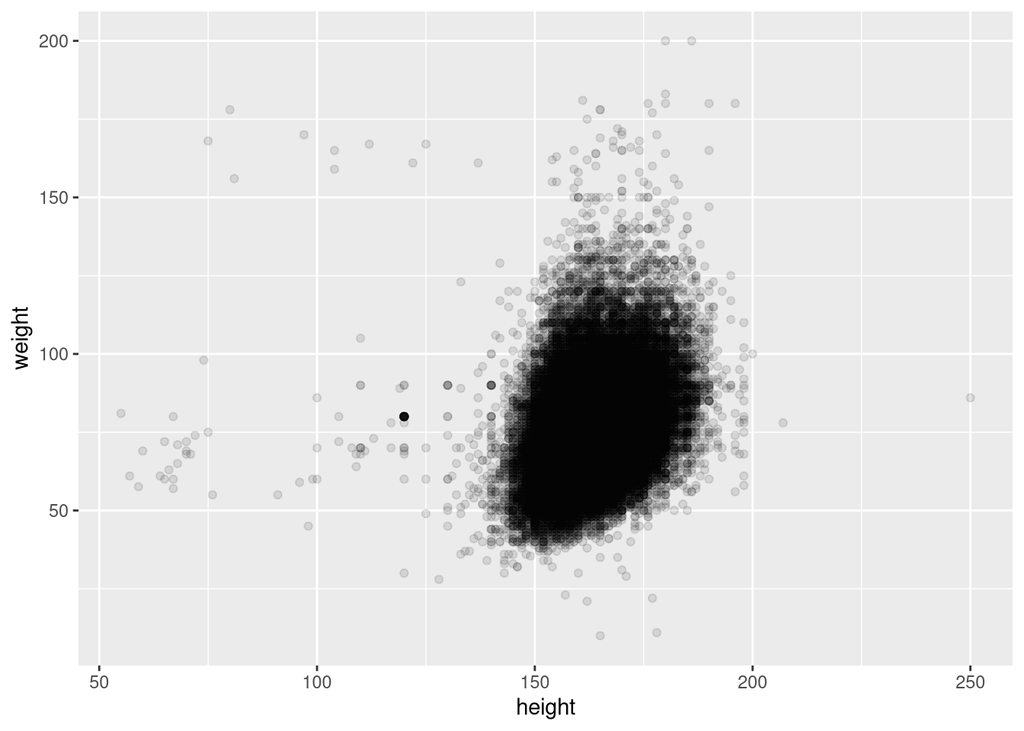

```r
  # To get a better look at the outlier here are two scatterplots that will show that there are some we may want to pull out
  ggplot(cardio_data, aes(x=height,y=weight)) +
    geom_point(alpha=0.1)
```

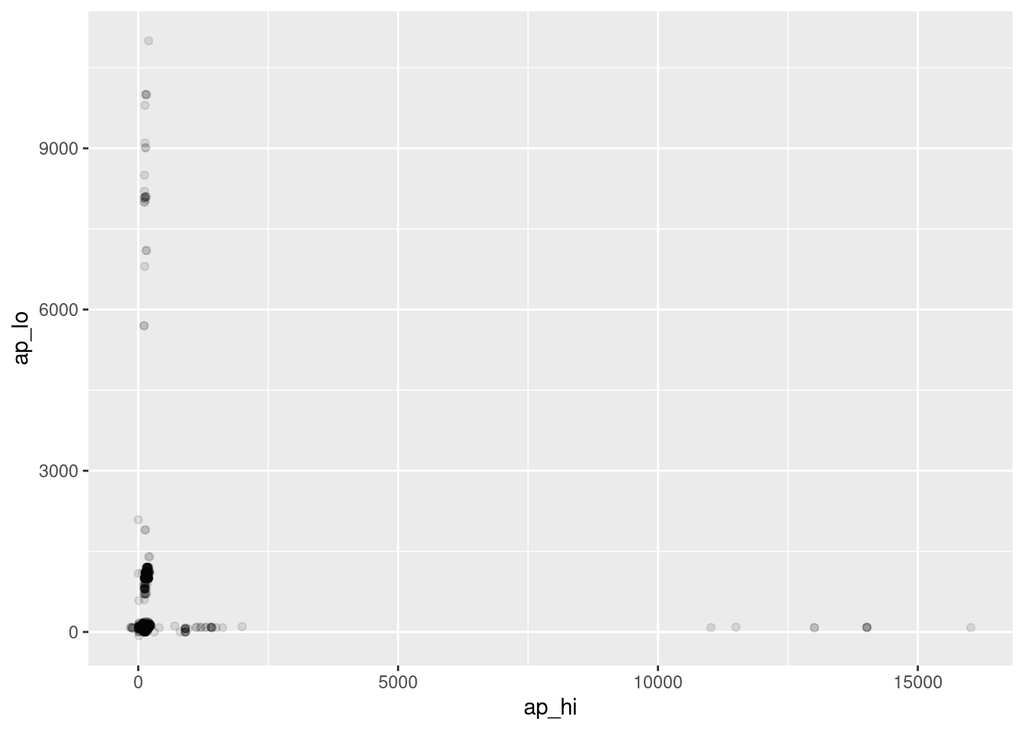

```r
  # And blood pressure, systolic (hi) and diastolic (lo) have some outliers that shouldn't exist like negative numbers or extremly high numbers
  # Otherwise this data would look very different distributed in the graph
  ggplot(cardio_data, aes(x=ap_hi,y=ap_lo)) +
    geom_point(alpha=0.1)
```

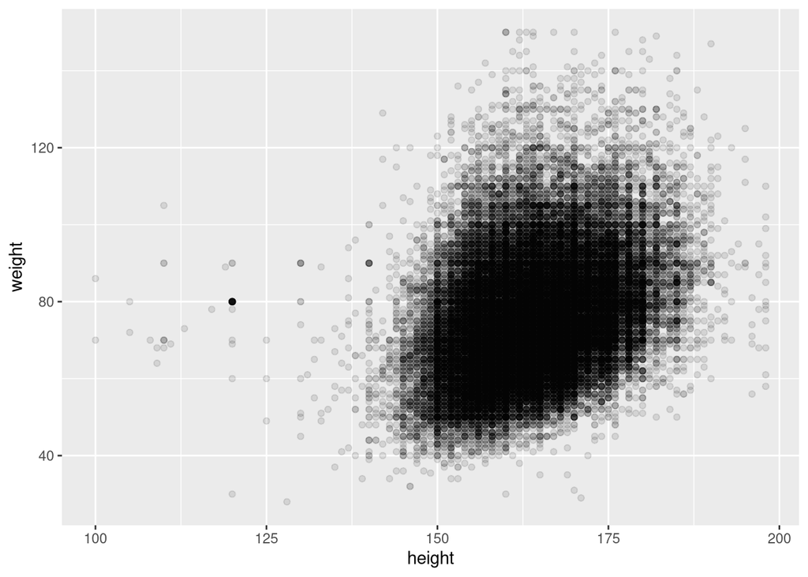

```r
  # For height and weight there is a high concentration in the center so I am going to start to pull out some records
  clean_cardio_data = cardio_data %>%
    # Removing those outlier based on height,
    filter(height>=100 & height<=200) %>%
    # There are a few outliers that have a low weight or even too heigh of a weight
    filter(weight>=25 & weight<=150) %>%
    # Going to filter by systolic blood pressure
    filter(ap_hi>=90 & ap_hi<=170) %>%
    # Finally by diastolic blood pressure
    filter(ap_lo>=65 & ap_lo<=105) %>%
    # Get non-duplicated records
    unique

  # Doing one last thing to ensure that the indicator for cardio is easy to handle by putting it as a factor
  clean_cardio_data$disease = factor(NA, levels=c(NA, "No", "Yes"))
  clean_cardio_data$disease[clean_cardio_data$cardio==1] = "Yes"
  clean_cardio_data$disease[clean_cardio_data$cardio==0] = "No"

  # It looks like there might be some more parsing down that we may need to do but both plots look much better
  ggplot(clean_cardio_data, aes(x=height,y=weight)) +
    geom_point(alpha=0.1)
```

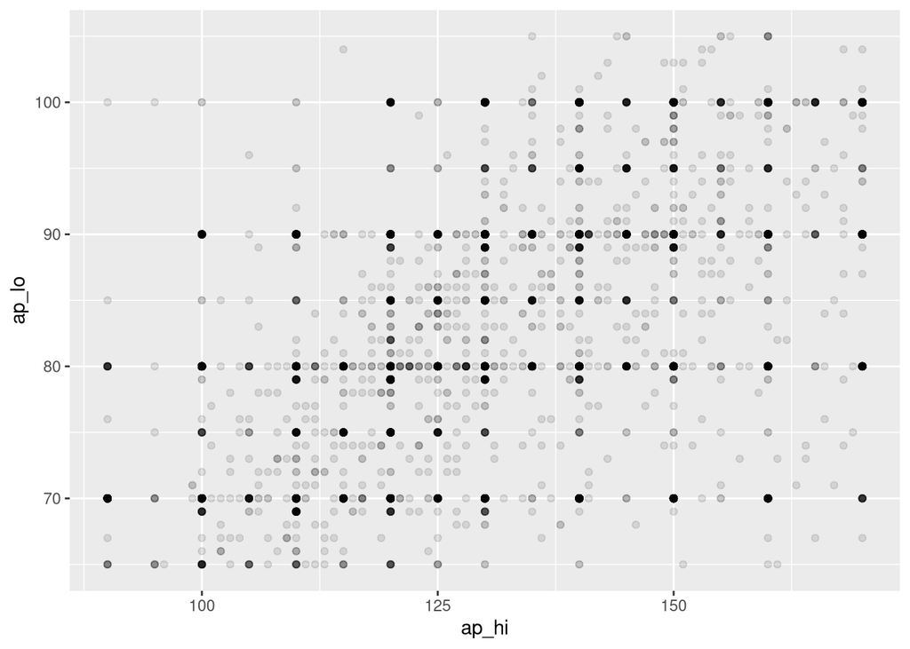

```r
  ggplot(clean_cardio_data, aes(x=ap_hi,y=ap_lo)) +
    geom_point(alpha=0.1)
```

```r
  summary(clean_cardio_data)
```

```
##        id             age            gender          height
##  Min.   :    0   Min.   :10859   Min.   :1.000   Min.   :100.0
##  1st Qu.:24930   1st Qu.:17720   1st Qu.:1.000   1st Qu.:159.0
##  Median :50020   Median :19716   Median :1.000   Median :165.0
##  Mean   :49970   Mean   :19492   Mean   :1.352   Mean   :164.5
##  3rd Qu.:74879   3rd Qu.:21343   3rd Qu.:2.000   3rd Qu.:170.0
##  Max.   :99999   Max.   :23713   Max.   :2.000   Max.   :198.0
##      weight          ap_hi           ap_lo         cholesterol
##  Min.   : 28.0   Min.   : 90.0   Min.   : 65.00   Min.   :1.000
##  1st Qu.: 65.0   1st Qu.:120.0   1st Qu.: 80.00   1st Qu.:1.000
##  Median : 72.0   Median :120.0   Median : 80.00   Median :1.000
##  Mean   : 74.2   Mean   :126.6   Mean   : 81.79   Mean   :1.364
##  3rd Qu.: 82.0   3rd Qu.:140.0   3rd Qu.: 90.00   3rd Qu.:1.000
##  Max.   :150.0   Max.   :170.0   Max.   :105.00   Max.   :3.000
##       gluc           smoke              alco             active
##  Min.   :1.000   Min.   :0.00000   Min.   :0.00000   Min.   :0.0000
##  1st Qu.:1.000   1st Qu.:0.00000   1st Qu.:0.00000   1st Qu.:1.0000
##  Median :1.000   Median :0.00000   Median :0.00000   Median :1.0000
##  Mean   :1.226   Mean   :0.08761   Mean   :0.05302   Mean   :0.8034
##  3rd Qu.:1.000   3rd Qu.:0.00000   3rd Qu.:0.00000   3rd Qu.:1.0000
##  Max.   :3.000   Max.   :1.00000   Max.   :1.00000   Max.   :1.0000
##      cardio       disease
##  Min.   :0.0000   No :32320
##  1st Qu.:0.0000   Yes:32110
##  Median :0.0000
##  Mean   :0.4984
##  3rd Qu.:1.0000
##  Max.   :1.0000
```

## Views of the Data

The data will be sliced in multiple ways for various uses. One way that I will be slicing the data will be into training and testing sets for modeling. But with that as well I plan to separate them into the two gender codes available to see if there are different patterns or relationships emerge from similar analyses, as well as seeing how the inclusion of some outliers may affect the accuracy of the models.

As for creating new points, I do not see a benefit since there really isn’t much data mining I can do, technically I can calculate BMI but this may be limited since it is directly related and calculated from weight, height, and age. Thus for this project there will be no new data points created.

## Machine Learning

I do plan on using machine learning to answer my questions, primarily because I want to see if kmeans or knn might be able to find patterns that aren’t obvious to me, and what model regression or otherwise can create the most accurate model.

## Looking for Initial Patterns

Next some simple noticeable patterns in visualizations and through usages of other commands will give more insights to non-obvious patterns.

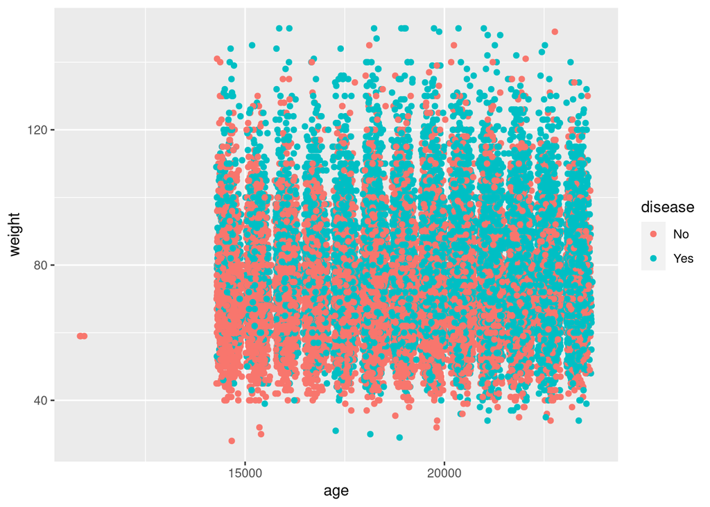

```r
  ggplot(clean_cardio_data,aes(x=age,y=weight, color=disease)) +
    geom_point()
```

From this initial visualization that I’ve rendered is using age on the x axis and weight on the y, with two colors depicting the detection of heart disease. A pattern we can pickout here is that the heavier and older the person, it seems that they are more prone to heart disease, since there is a large amount of clustering of the color that was positive for heart disease in the top right corner. Another thing we can see is that across all weights the detection of heart disease at nearly all weights the later in life they get.

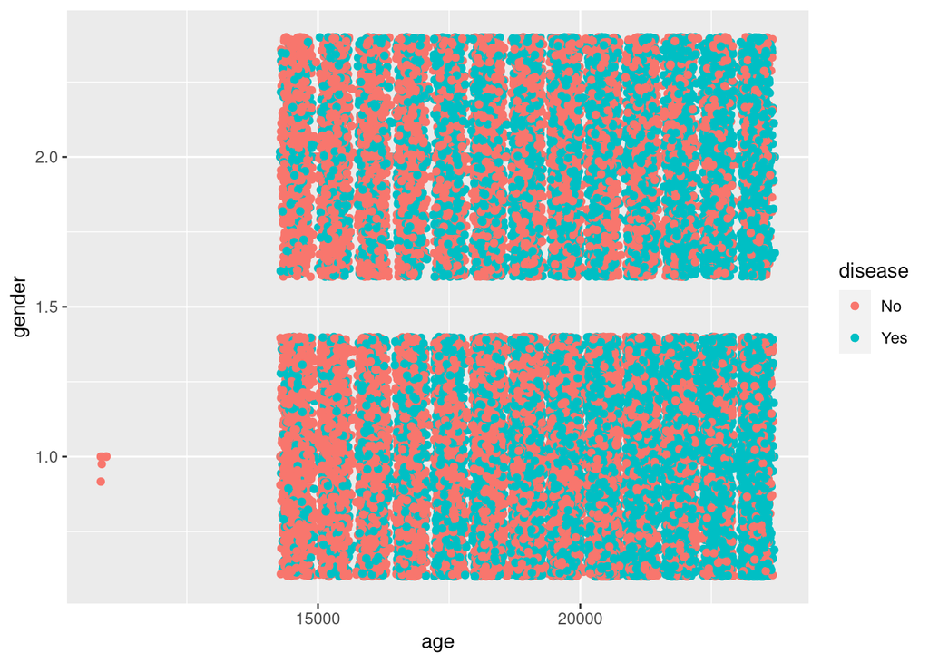

```r
  ggplot(clean_cardio_data,aes(x=age,y=gender, color=disease)) +
    geom_point() +
    geom_jitter()
```

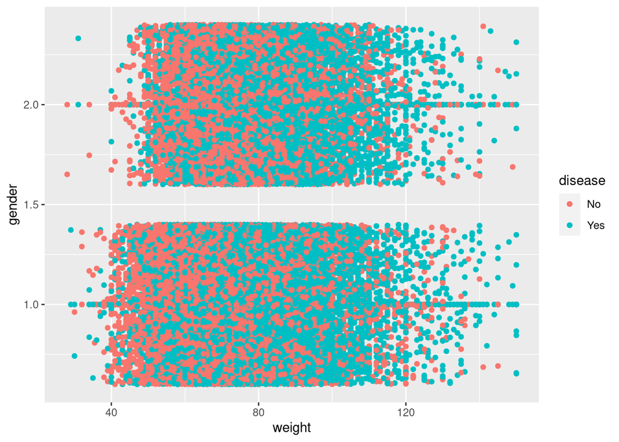

```r
  ggplot(clean_cardio_data,aes(x=weight,y=gender, color=disease)) +
    geom_point() +
    geom_jitter()
```

```r
  # This is a bit like swallowing the ocean but we are going to ignore those records in reference to the cardio variable and
  var(clean_cardio_data[setdiff(colnames(clean_cardio_data), c("disease")) ])
```

```
##                        id           age        gender        height
## id           8.325654e+08  280799.56767  5.412516e+01  -468.6116880
## age          2.807996e+05 6044502.89235 -3.790633e+01 -1800.2639094
## gender       5.412516e+01     -37.90633  2.280381e-01     1.9356073
## height      -4.686117e+02   -1800.26391  1.935607e+00    62.9699975
## weight       4.762672e+02    1575.99997  1.023406e+00    33.4089499
## ap_hi        1.714944e+03    7135.87682  3.021750e-01    -0.1262669
## ap_lo        4.855438e+02    2741.65317  1.801225e-01     0.9065841
## cholesterol  1.133925e+02     255.54365 -1.338251e-02    -0.3116378
## gluc         4.214573e+01     136.09952 -6.664102e-03    -0.1073197
## smoke       -2.362485e+01     -34.91996  4.547844e-02     0.4314055
## alco         3.963718e+00     -16.43621  1.814829e-02     0.1713778
## active       4.073876e+01      -9.47917  1.145534e-03    -0.0340756
## cardio       7.507477e+01     286.32449 -5.131505e-04    -0.0829503
##                    weight         ap_hi         ap_lo   cholesterol
## id           476.26724305  1.714944e+03  4.855438e+02 113.392467006
## age         1575.99996970  7.135877e+03  2.741653e+03 255.543654082
## gender         1.02340607  3.021750e-01  1.801225e-01  -0.013382507
## height        33.40894992 -1.262669e-01  9.065841e-01  -0.311637795
## weight       193.59005069  4.897091e+01  2.385204e+01   1.304117618
## ap_hi         48.97091033  2.069125e+02  7.839438e+01   1.904083859
## ap_lo         23.85203830  7.839438e+01  5.947750e+01   0.830902728
## cholesterol    1.30411762  1.904084e+00  8.309027e-01   0.462777337
## gluc           0.81329331  7.270765e-01  2.971494e-01   0.175812902
## smoke          0.26962638  9.057735e-02  4.643789e-02   0.001657268
## alco           0.20691998  9.773359e-02  5.756644e-02   0.004900002
## active        -0.09484962  7.555507e-03 -3.287514e-05   0.002431572
## cardio         1.16146140  3.106981e+00  1.299409e+00   0.074558768
##                      gluc         smoke          alco        active
## id           42.145734805 -23.624846720   3.963718103  4.073876e+01
## age         136.099523838 -34.919956407 -16.436207297 -9.479170e+00
## gender       -0.006664102   0.045478442   0.018148292  1.145534e-03
## height       -0.107319656   0.431405480   0.171377830 -3.407560e-02
## weight        0.813293311   0.269626382   0.206919983 -9.484962e-02
## ap_hi         0.727076492   0.090577350   0.097733593  7.555507e-03
## ap_lo         0.297149426   0.046437887   0.057566435 -3.287514e-05
## cholesterol   0.175812902   0.001657268   0.004900002  2.431572e-03
## gluc          0.327921314  -0.001097939   0.001058731 -1.676898e-03
## smoke        -0.001097939   0.079939411   0.021600661  2.727418e-03
## alco          0.001058731   0.021600661   0.050208568  2.181252e-03
## active       -0.001676898   0.002727418   0.002181252  1.579421e-01
## cardio        0.024642509  -0.002705311  -0.001170793 -7.475539e-03
##                    cardio
## id           7.507477e+01
## age          2.863245e+02
## gender      -5.131505e-04
## height      -8.295030e-02
## weight       1.161461e+00
## ap_hi        3.106981e+00
## ap_lo        1.299409e+00
## cholesterol  7.455877e-02
## gluc         2.464251e-02
## smoke       -2.705311e-03
## alco        -1.170793e-03
## active      -7.475539e-03
## cardio       2.500012e-01
```

However, we can see with the variance calculations that there is a high amount of variance between the age of a person and the cardio variable. In comparison as well the weight variable does have some variance with cardio that suggests that they may have a fairly positive relationship here, as well as their relationship with both systolic and diastolic blood pressure. The rest of the relationships seem to have extremely small amounts of variance with the cardio indicator are so very small and go just barely positive or negative. This doesn’t really prove much except some strength and directionality of the variance of variables with cardio. This does support what we were able to visualize previously.

```r
  cor(clean_cardio_data[setdiff(colnames(clean_cardio_data), c("disease")) ])
```

```
##                        id          age       gender       height       weight
## id           1.0000000000  0.003958284  0.003928134 -0.002046619  0.001186315
## age          0.0039582840  1.000000000 -0.032287004 -0.092276060  0.046071717
## gender       0.0039281339 -0.032287004  1.000000000  0.510795071  0.154029089
## height      -0.0020466194 -0.092276060  0.510795071  1.000000000  0.302589930
## weight       0.0011863150  0.046071717  0.154029089  0.302589930  1.000000000
## ap_hi        0.0041318780  0.201777958  0.043990758 -0.001106189  0.244682739
## ap_lo        0.0021819403  0.144595857  0.048908899  0.014813746  0.222283697
## cholesterol  0.0057768218  0.152791349 -0.041195304 -0.057729427  0.137780959
## gluc         0.0025507014  0.096669949 -0.024369864 -0.023617157  0.102075346
## smoke       -0.0028958718 -0.050235754  0.336838232  0.192281874  0.068539415
## alco         0.0006130624 -0.029835437  0.169606747  0.096382654  0.066370028
## active       0.0035526275 -0.009701550  0.006036086 -0.010805074 -0.017153201
## cardio       0.0052037182  0.232920191 -0.002149166 -0.020906438  0.166952220
##                    ap_hi         ap_lo  cholesterol         gluc        smoke
## id           0.004131878  2.181940e-03  0.005776822  0.002550701 -0.002895872
## age          0.201777958  1.445959e-01  0.152791349  0.096669949 -0.050235754
## gender       0.043990758  4.890890e-02 -0.041195304 -0.024369864  0.336838232
## height      -0.001106189  1.481375e-02 -0.057729427 -0.023617157  0.192281874
## weight       0.244682739  2.222837e-01  0.137780959  0.102075346  0.068539415
## ap_hi        1.000000000  7.066677e-01  0.194583810  0.088267729  0.022271312
## ap_lo        0.706667682  1.000000e+00  0.158375418  0.067284294  0.021296861
## cholesterol  0.194583810  1.583754e-01  1.000000000  0.451315114  0.008616407
## gluc         0.088267729  6.728429e-02  0.451315114  1.000000000 -0.006781298
## smoke        0.022271312  2.129686e-02  0.008616407 -0.006781298  1.000000000
## alco         0.030322264  3.331226e-02  0.032145584  0.008251100  0.340955459
## active       0.001321665 -1.072611e-05  0.008993984 -0.007368395  0.024272938
## cardio       0.431990549  3.369756e-01  0.219200537  0.086065488 -0.019136639
##                      alco        active       cardio
## id           0.0006130624  3.552628e-03  0.005203718
## age         -0.0298354365 -9.701550e-03  0.232920191
## gender       0.1696067469  6.036086e-03 -0.002149166
## height       0.0963826542 -1.080507e-02 -0.020906438
## weight       0.0663700276 -1.715320e-02  0.166952220
## ap_hi        0.0303222637  1.321665e-03  0.431990549
## ap_lo        0.0333122562 -1.072611e-05  0.336975591
## cholesterol  0.0321455845  8.993984e-03  0.219200537
## gluc         0.0082511002 -7.368395e-03  0.086065488
## smoke        0.3409554593  2.427294e-02 -0.019136639
## alco         1.0000000000  2.449447e-02 -0.010450093
## active       0.0244944661  1.000000e+00 -0.037620323
## cardio      -0.0104500932 -3.762032e-02  1.000000000
```

It seems as if age does have some small relationship with age, weight, cholesterol, and blood pressure readings with cardio. Another thing to note here though that might cause some interference in modeling is that these variables have a high amount of covariance with each other, which may indicatete that these variables are not independent with each other.

## Splitting Datasets for Modeling

For cross-validation to make sure created models aren’t over-fitted we need to split the data into a training set and a testing set. This will be relatively simple since we have such a large data set to sample from, and for this exercise I am just putting 80% of the records into the training data and the remainder to be used in the testing data.

```r
  # Going to start split the data very quickly into to two sets with 80% in training and 20% in test
  training_index1 = sample(1:nrow(clean_cardio_data), size=round(nrow(clean_cardio_data)*0.8))
  train_cardio_data = clean_cardio_data[ training_index1, ]
  test_cardio_data  = clean_cardio_data[-training_index1, ]
```

## Simple Logistic Regression Models

What we are going to do here is create some simple initial models with a single variable being used to predict whether or not that individual has cardiovascular disease. Creation of the model will use the training data and then the prediction will be done with the test data, with a confusion matrix being created for evaluation of the model in comparison to the actuals.

```r
  # Now we are going to checkout various simple linear models and look at their accuracy
  # Will not look at all of them but those that I suspect would be helpful indicators in a larger model

  s_glm1 = glm(cardio ~ age, data=train_cardio_data, family=binomial)
  summary(s_glm1)
```

```
##
## Call:
## glm(formula = cardio ~ age, family = binomial, data = train_cardio_data)
##
## Deviance Residuals:
##     Min       1Q   Median       3Q      Max
## -1.5437  -1.1366  -0.7793   1.1038   1.6385
##
## Coefficients:
##               Estimate Std. Error z value Pr(>|z|)
## (Intercept) -3.878e+00  7.503e-02  -51.69   <2e-16 ***
## age          1.988e-04  3.814e-06   52.13   <2e-16 ***
## ---
## Signif. codes:  0 '***' 0.001 '**' 0.01 '*' 0.05 '.' 0.1 ' ' 1
##
## (Dispersion parameter for binomial family taken to be 1)
##
##     Null deviance: 71455  on 51543  degrees of freedom
## Residual deviance: 68562  on 51542  degrees of freedom
## AIC: 68566
##
## Number of Fisher Scoring iterations: 4
```

```r
  confusionMatrix(table(test_cardio_data$cardio, round(predict(s_glm1, test_cardio_data, type="response"))) )
```

```
## Confusion Matrix and Statistics
##
##
##        0    1
##   0 3499 3042
##   1 2240 4105
##
##                Accuracy : 0.5901
##                  95% CI : (0.5815, 0.5986)
##     No Information Rate : 0.5546
##     P-Value [Acc > NIR] : 2.415e-16
##
##                   Kappa : 0.1816
##
##  Mcnemar's Test P-Value : < 2.2e-16
##
##             Sensitivity : 0.6097
##             Specificity : 0.5744
##          Pos Pred Value : 0.5349
##          Neg Pred Value : 0.6470
##              Prevalence : 0.4454
##          Detection Rate : 0.2715
##    Detection Prevalence : 0.5076
##       Balanced Accuracy : 0.5920
##
##        'Positive' Class : 0
##
```

```r
  s_glm2 = glm(cardio ~ gender, data=train_cardio_data, family=binomial)
  summary(s_glm2)
```

```
##
## Call:
## glm(formula = cardio ~ gender, family = binomial, data = train_cardio_data)
##
## Deviance Residuals:
##    Min      1Q  Median      3Q     Max
## -1.179  -1.179  -1.173   1.175   1.182
##
## Coefficients:
##             Estimate Std. Error z value Pr(>|z|)
## (Intercept)  0.01972    0.02645   0.746    0.456
## gender      -0.01499    0.01845  -0.812    0.417
##
## (Dispersion parameter for binomial family taken to be 1)
##
##     Null deviance: 71455  on 51543  degrees of freedom
## Residual deviance: 71454  on 51542  degrees of freedom
## AIC: 71458
##
## Number of Fisher Scoring iterations: 3
```

```r
  confusionMatrix(table(test_cardio_data$cardio, round(predict(s_glm2, test_cardio_data, type="response"))) )
```

```
## Confusion Matrix and Statistics
##
##
##        0    1
##   0 2293 4248
##   1 2246 4099
##
##                Accuracy : 0.496
##                  95% CI : (0.4874, 0.5047)
##     No Information Rate : 0.6478
##     P-Value [Acc > NIR] : 1
##
##                   Kappa : -0.0034
##
##  Mcnemar's Test P-Value : <2e-16
##
##             Sensitivity : 0.5052
##             Specificity : 0.4911
##          Pos Pred Value : 0.3506
##          Neg Pred Value : 0.6460
##              Prevalence : 0.3522
##          Detection Rate : 0.1779
##    Detection Prevalence : 0.5076
##       Balanced Accuracy : 0.4981
##
##        'Positive' Class : 0
##
```

```r
  s_glm3 = glm(cardio ~ height, data=train_cardio_data, family=binomial)
  summary(s_glm3)
```

```
##
## Call:
## glm(formula = cardio ~ height, family = binomial, data = train_cardio_data)
##
## Deviance Residuals:
##    Min      1Q  Median      3Q     Max
## -1.345  -1.176  -1.098   1.179   1.264
##
## Coefficients:
##              Estimate Std. Error z value Pr(>|z|)
## (Intercept)  0.982713   0.183182   5.365 8.11e-08 ***
## height      -0.005978   0.001112  -5.374 7.71e-08 ***
## ---
## Signif. codes:  0 '***' 0.001 '**' 0.01 '*' 0.05 '.' 0.1 ' ' 1
##
## (Dispersion parameter for binomial family taken to be 1)
##
##     Null deviance: 71455  on 51543  degrees of freedom
## Residual deviance: 71426  on 51542  degrees of freedom
## AIC: 71430
##
## Number of Fisher Scoring iterations: 3
```

```r
  confusionMatrix(table(test_cardio_data$cardio, round(predict(s_glm3, test_cardio_data, type="response"))) )
```

```
## Confusion Matrix and Statistics
##
##
##        0    1
##   0 3396 3145
##   1 3266 3079
##
##                Accuracy : 0.5025
##                  95% CI : (0.4938, 0.5112)
##     No Information Rate : 0.517
##     P-Value [Acc > NIR] : 0.9995
##
##                   Kappa : 0.0045
##
##  Mcnemar's Test P-Value : 0.1339
##
##             Sensitivity : 0.5098
##             Specificity : 0.4947
##          Pos Pred Value : 0.5192
##          Neg Pred Value : 0.4853
##              Prevalence : 0.5170
##          Detection Rate : 0.2635
##    Detection Prevalence : 0.5076
##       Balanced Accuracy : 0.5022
##
##        'Positive' Class : 0
##
```

```r
  s_glm4 = glm(cardio ~ weight, data=train_cardio_data, family=binomial)
  summary(s_glm4)
```

```
##
## Call:
## glm(formula = cardio ~ weight, family = binomial, data = train_cardio_data)
##
## Deviance Residuals:
##     Min       1Q   Median       3Q      Max
## -2.0072  -1.1341  -0.8098   1.1680   1.6780
##
## Coefficients:
##               Estimate Std. Error z value Pr(>|z|)
## (Intercept) -1.8519734  0.0503139  -36.81   <2e-16 ***
## weight       0.0249885  0.0006701   37.29   <2e-16 ***
## ---
## Signif. codes:  0 '***' 0.001 '**' 0.01 '*' 0.05 '.' 0.1 ' ' 1
##
## (Dispersion parameter for binomial family taken to be 1)
##
##     Null deviance: 71455  on 51543  degrees of freedom
## Residual deviance: 69981  on 51542  degrees of freedom
## AIC: 69985
##
## Number of Fisher Scoring iterations: 4
```

```r
  confusionMatrix(table(test_cardio_data$cardio, round(predict(s_glm4, test_cardio_data, type="response"))) )
```

```
## Confusion Matrix and Statistics
##
##
##        0    1
##   0 4113 2428
##   1 3147 3198
##
##                Accuracy : 0.5674
##                  95% CI : (0.5588, 0.5759)
##     No Information Rate : 0.5634
##     P-Value [Acc > NIR] : 0.1849
##
##                   Kappa : 0.133
##
##  Mcnemar's Test P-Value : <2e-16
##
##             Sensitivity : 0.5665
##             Specificity : 0.5684
##          Pos Pred Value : 0.6288
##          Neg Pred Value : 0.5040
##              Prevalence : 0.5634
##          Detection Rate : 0.3192
##    Detection Prevalence : 0.5076
##       Balanced Accuracy : 0.5675
##
##        'Positive' Class : 0
##
```

```r
  s_glm5 = glm(cardio ~ ap_hi, data=train_cardio_data, family=binomial)
  summary(s_glm5)
```

```
##
## Call:
## glm(formula = cardio ~ ap_hi, family = binomial, data = train_cardio_data)
##
## Deviance Residuals:
##     Min       1Q   Median       3Q      Max
## -2.6214  -0.9910  -0.3485   1.0465   2.3798
##
## Coefficients:
##               Estimate Std. Error z value Pr(>|z|)
## (Intercept) -9.7171131  0.1091313  -89.04   <2e-16 ***
## ap_hi        0.0771781  0.0008706   88.65   <2e-16 ***
## ---
## Signif. codes:  0 '***' 0.001 '**' 0.01 '*' 0.05 '.' 0.1 ' ' 1
##
## (Dispersion parameter for binomial family taken to be 1)
##
##     Null deviance: 71455  on 51543  degrees of freedom
## Residual deviance: 60461  on 51542  degrees of freedom
## AIC: 60465
##
## Number of Fisher Scoring iterations: 4
```

```r
  confusionMatrix(table(test_cardio_data$cardio, round(predict(s_glm5, test_cardio_data, type="response"))) )
```

```
## Confusion Matrix and Statistics
##
##
##        0    1
##   0 5167 1374
##   1 2503 3842
##
##                Accuracy : 0.6991
##                  95% CI : (0.6911, 0.707)
##     No Information Rate : 0.5952
##     P-Value [Acc > NIR] : < 2.2e-16
##
##                   Kappa : 0.3965
##
##  Mcnemar's Test P-Value : < 2.2e-16
##
##             Sensitivity : 0.6737
##             Specificity : 0.7366
##          Pos Pred Value : 0.7899
##          Neg Pred Value : 0.6055
##              Prevalence : 0.5952
##          Detection Rate : 0.4010
##    Detection Prevalence : 0.5076
##       Balanced Accuracy : 0.7051
##
##        'Positive' Class : 0
##
```

```r
  s_glm6 = glm(cardio ~ ap_lo, data=train_cardio_data, family=binomial)
  summary(s_glm6)
```

```
##
## Call:
## glm(formula = cardio ~ ap_lo, family = binomial, data = train_cardio_data)
##
## Deviance Residuals:
##     Min       1Q   Median       3Q      Max
## -2.2041  -1.1075  -0.5877   1.2489   1.9190
##
## Coefficients:
##              Estimate Std. Error z value Pr(>|z|)
## (Intercept) -8.177566   0.113121  -72.29   <2e-16 ***
## ap_lo        0.100137   0.001384   72.34   <2e-16 ***
## ---
## Signif. codes:  0 '***' 0.001 '**' 0.01 '*' 0.05 '.' 0.1 ' ' 1
##
## (Dispersion parameter for binomial family taken to be 1)
##
##     Null deviance: 71455  on 51543  degrees of freedom
## Residual deviance: 65117  on 51542  degrees of freedom
## AIC: 65121
##
## Number of Fisher Scoring iterations: 4
```

```r
  confusionMatrix(table(test_cardio_data$cardio, round(predict(s_glm6, test_cardio_data, type="response"))) )
```

```
## Confusion Matrix and Statistics
##
##
##        0    1
##   0 5587  954
##   1 3599 2746
##
##                Accuracy : 0.6467
##                  95% CI : (0.6383, 0.6549)
##     No Information Rate : 0.7129
##     P-Value [Acc > NIR] : 1
##
##                   Kappa : 0.2887
##
##  Mcnemar's Test P-Value : <2e-16
##
##             Sensitivity : 0.6082
##             Specificity : 0.7422
##          Pos Pred Value : 0.8542
##          Neg Pred Value : 0.4328
##              Prevalence : 0.7129
##          Detection Rate : 0.4336
##    Detection Prevalence : 0.5076
##       Balanced Accuracy : 0.6752
##
##        'Positive' Class : 0
##
```

```r
  s_glm7 = glm(cardio ~ cholesterol, data=train_cardio_data, family=binomial)
  summary(s_glm7)
```

```
##
## Call:
## glm(formula = cardio ~ cholesterol, family = binomial, data = train_cardio_data)
##
## Deviance Residuals:
##    Min      1Q  Median      3Q     Max
## -1.693  -1.076  -1.076   1.282   1.282
##
## Coefficients:
##             Estimate Std. Error z value Pr(>|z|)
## (Intercept) -0.94453    0.02098  -45.02   <2e-16 ***
## cholesterol  0.70186    0.01446   48.53   <2e-16 ***
## ---
## Signif. codes:  0 '***' 0.001 '**' 0.01 '*' 0.05 '.' 0.1 ' ' 1
##
## (Dispersion parameter for binomial family taken to be 1)
##
##     Null deviance: 71455  on 51543  degrees of freedom
## Residual deviance: 68823  on 51542  degrees of freedom
## AIC: 68827
##
## Number of Fisher Scoring iterations: 4
```

```r
  confusionMatrix(table(test_cardio_data$cardio, round(predict(s_glm7, test_cardio_data, type="response"))) )
```

```
## Confusion Matrix and Statistics
##
##
##        0    1
##   0 5445 1096
##   1 4231 2114
##
##                Accuracy : 0.5866
##                  95% CI : (0.578, 0.5951)
##     No Information Rate : 0.7509
##     P-Value [Acc > NIR] : 1
##
##                   Kappa : 0.1669
##
##  Mcnemar's Test P-Value : <2e-16
##
##             Sensitivity : 0.5627
##             Specificity : 0.6586
##          Pos Pred Value : 0.8324
##          Neg Pred Value : 0.3332
##              Prevalence : 0.7509
##          Detection Rate : 0.4226
##    Detection Prevalence : 0.5076
##       Balanced Accuracy : 0.6106
##
##        'Positive' Class : 0
##
```

```r
  s_glm8 = glm(cardio ~ gluc, data=train_cardio_data, family=binomial)
  summary(s_glm8)
```

```
##
## Call:
## glm(formula = cardio ~ gluc, family = binomial, data = train_cardio_data)
##
## Deviance Residuals:
##    Min      1Q  Median      3Q     Max
## -1.419  -1.148  -1.148   1.207   1.207
##
## Coefficients:
##             Estimate Std. Error z value Pr(>|z|)
## (Intercept) -0.37970    0.02116  -17.94   <2e-16 ***
## gluc         0.31039    0.01583   19.61   <2e-16 ***
## ---
## Signif. codes:  0 '***' 0.001 '**' 0.01 '*' 0.05 '.' 0.1 ' ' 1
##
## (Dispersion parameter for binomial family taken to be 1)
##
##     Null deviance: 71455  on 51543  degrees of freedom
## Residual deviance: 71059  on 51542  degrees of freedom
## AIC: 71063
##
## Number of Fisher Scoring iterations: 4
```

```r
  confusionMatrix(table(test_cardio_data$cardio, round(predict(s_glm8, test_cardio_data, type="response"))) )
```

```
## Confusion Matrix and Statistics
##
##
##        0    1
##   0 5739  802
##   1 5190 1155
##
##                Accuracy : 0.535
##                  95% CI : (0.5263, 0.5436)
##     No Information Rate : 0.8481
##     P-Value [Acc > NIR] : 1
##
##                   Kappa : 0.06
##
##  Mcnemar's Test P-Value : <2e-16
##
##             Sensitivity : 0.5251
##             Specificity : 0.5902
##          Pos Pred Value : 0.8774
##          Neg Pred Value : 0.1820
##              Prevalence : 0.8481
##          Detection Rate : 0.4454
##    Detection Prevalence : 0.5076
##       Balanced Accuracy : 0.5577
##
##        'Positive' Class : 0
##
```

```r
  s_glm9 = glm(cardio ~ active, data=train_cardio_data, family=binomial)
  summary(s_glm9)
```

```
##
## Call:
## glm(formula = cardio ~ active, family = binomial, data = train_cardio_data)
##
## Deviance Residuals:
##    Min      1Q  Median      3Q     Max
## -1.248  -1.160  -1.160   1.195   1.195
##
## Coefficients:
##             Estimate Std. Error z value Pr(>|z|)
## (Intercept)  0.16437    0.01995   8.241   <2e-16 ***
## active      -0.20513    0.02224  -9.225   <2e-16 ***
## ---
## Signif. codes:  0 '***' 0.001 '**' 0.01 '*' 0.05 '.' 0.1 ' ' 1
##
## (Dispersion parameter for binomial family taken to be 1)
##
##     Null deviance: 71455  on 51543  degrees of freedom
## Residual deviance: 71370  on 51542  degrees of freedom
## AIC: 71374
##
## Number of Fisher Scoring iterations: 3
```

```r
  confusionMatrix(table(test_cardio_data$cardio, round(predict(s_glm9, test_cardio_data, type="response"))) )
```

```
## Confusion Matrix and Statistics
##
##
##        0    1
##   0 5315 1226
##   1 5027 1318
##
##                Accuracy : 0.5147
##                  95% CI : (0.5061, 0.5234)
##     No Information Rate : 0.8026
##     P-Value [Acc > NIR] : 1
##
##                   Kappa : 0.0205
##
##  Mcnemar's Test P-Value : <2e-16
##
##             Sensitivity : 0.5139
##             Specificity : 0.5181
##          Pos Pred Value : 0.8126
##          Neg Pred Value : 0.2077
##              Prevalence : 0.8026
##          Detection Rate : 0.4125
##    Detection Prevalence : 0.5076
##       Balanced Accuracy : 0.5160
##
##        'Positive' Class : 0
##
```

The above models and analysis had confirmed something that I was fairly certain of, and that is that no single variable alone is a great indicator of heart disease. Most are just above a coin toss chance of predicting correctly, just around 50%, with exception to systolic blood pressure (ap_hi) which had a fairly high prediction rating in comparison (~70% during my initial tests). This could paritally be due to some statistical anomaly of sampling.

## Multiple Logistic Regression Modeling

```r
  # Now we are going to be using various models with different formulas and try to findout which one is most accurate

  # This one is one of the more promising ones I think because it's puretly objective and oversational features that seemed to have patterns in visualizations and previous models
  m_glm1 = glm(cardio ~ age + ap_hi + ap_lo, train_cardio_data, family=binomial)
  summary(m_glm1)
```

```
##
## Call:
## glm(formula = cardio ~ age + ap_hi + ap_lo, family = binomial,
##     data = train_cardio_data)
##
## Deviance Residuals:
##     Min       1Q   Median       3Q      Max
## -2.7809  -0.9607  -0.2616   0.9607   2.5608
##
## Coefficients:
##               Estimate Std. Error z value Pr(>|z|)
## (Intercept) -1.282e+01  1.487e-01 -86.182   <2e-16 ***
## age          1.539e-04  4.204e-06  36.607   <2e-16 ***
## ap_hi        6.644e-02  1.143e-03  58.120   <2e-16 ***
## ap_lo        1.768e-02  1.915e-03   9.234   <2e-16 ***
## ---
## Signif. codes:  0 '***' 0.001 '**' 0.01 '*' 0.05 '.' 0.1 ' ' 1
##
## (Dispersion parameter for binomial family taken to be 1)
##
##     Null deviance: 71455  on 51543  degrees of freedom
## Residual deviance: 58996  on 51540  degrees of freedom
## AIC: 59004
##
## Number of Fisher Scoring iterations: 4
```

```r
  confusionMatrix(table(test_cardio_data$cardio, round(predict(m_glm1, test_cardio_data, type="response"))) )
```

```
## Confusion Matrix and Statistics
##
##
##        0    1
##   0 5024 1517
##   1 2285 4060
##
##                Accuracy : 0.705
##                  95% CI : (0.697, 0.7128)
##     No Information Rate : 0.5672
##     P-Value [Acc > NIR] : < 2.2e-16
##
##                   Kappa : 0.4087
##
##  Mcnemar's Test P-Value : < 2.2e-16
##
##             Sensitivity : 0.6874
##             Specificity : 0.7280
##          Pos Pred Value : 0.7681
##          Neg Pred Value : 0.6399
##              Prevalence : 0.5672
##          Detection Rate : 0.3899
##    Detection Prevalence : 0.5076
##       Balanced Accuracy : 0.7077
##
##        'Positive' Class : 0
##
```

```r
  m_glm2 = glm(cardio ~ age + gender + weight + ap_hi + ap_lo, train_cardio_data, family=binomial)
  summary(m_glm2)
```

```
##
## Call:
## glm(formula = cardio ~ age + gender + weight + ap_hi + ap_lo,
##     family = binomial, data = train_cardio_data)
##
## Deviance Residuals:
##     Min       1Q   Median       3Q      Max
## -2.9353  -0.9468  -0.2553   0.9551   2.5533
##
## Coefficients:
##               Estimate Std. Error z value Pr(>|z|)
## (Intercept) -1.315e+01  1.544e-01 -85.176  < 2e-16 ***
## age          1.539e-04  4.223e-06  36.439  < 2e-16 ***
## gender      -1.352e-01  2.120e-02  -6.376 1.81e-10 ***
## weight       1.195e-02  7.637e-04  15.647  < 2e-16 ***
## ap_hi        6.462e-02  1.147e-03  56.347  < 2e-16 ***
## ap_lo        1.601e-02  1.921e-03   8.336  < 2e-16 ***
## ---
## Signif. codes:  0 '***' 0.001 '**' 0.01 '*' 0.05 '.' 0.1 ' ' 1
##
## (Dispersion parameter for binomial family taken to be 1)
##
##     Null deviance: 71455  on 51543  degrees of freedom
## Residual deviance: 58731  on 51538  degrees of freedom
## AIC: 58743
##
## Number of Fisher Scoring iterations: 4
```

```r
  confusionMatrix(table(test_cardio_data$cardio, round(predict(m_glm2, test_cardio_data, type="response"))) )
```

```
## Confusion Matrix and Statistics
##
##
##        0    1
##   0 4986 1555
##   1 2234 4111
##
##                Accuracy : 0.706
##                  95% CI : (0.698, 0.7138)
##     No Information Rate : 0.5603
##     P-Value [Acc > NIR] : < 2.2e-16
##
##                   Kappa : 0.4108
##
##  Mcnemar's Test P-Value : < 2.2e-16
##
##             Sensitivity : 0.6906
##             Specificity : 0.7256
##          Pos Pred Value : 0.7623
##          Neg Pred Value : 0.6479
##              Prevalence : 0.5603
##          Detection Rate : 0.3869
##    Detection Prevalence : 0.5076
##       Balanced Accuracy : 0.7081
##
##        'Positive' Class : 0
##
```

```r
  m_glm3 = glm(cardio ~ age + gender + weight + ap_hi + ap_lo + cholesterol, train_cardio_data, family=binomial)
  summary(m_glm3)
```

```
##
## Call:
## glm(formula = cardio ~ age + gender + weight + ap_hi + ap_lo +
##     cholesterol, family = binomial, data = train_cardio_data)
##
## Deviance Residuals:
##     Min       1Q   Median       3Q      Max
## -2.9606  -0.9193  -0.2580   0.9258   2.5419
##
## Coefficients:
##               Estimate Std. Error z value Pr(>|z|)
## (Intercept) -1.307e+01  1.550e-01 -84.357  < 2e-16 ***
## age          1.418e-04  4.269e-06  33.227  < 2e-16 ***
## gender      -1.008e-01  2.141e-02  -4.706 2.53e-06 ***
## weight       9.888e-03  7.737e-04  12.781  < 2e-16 ***
## ap_hi        6.232e-02  1.150e-03  54.197  < 2e-16 ***
## ap_lo        1.528e-02  1.936e-03   7.892 2.98e-15 ***
## cholesterol  4.551e-01  1.600e-02  28.443  < 2e-16 ***
## ---
## Signif. codes:  0 '***' 0.001 '**' 0.01 '*' 0.05 '.' 0.1 ' ' 1
##
## (Dispersion parameter for binomial family taken to be 1)
##
##     Null deviance: 71455  on 51543  degrees of freedom
## Residual deviance: 57886  on 51537  degrees of freedom
## AIC: 57900
##
## Number of Fisher Scoring iterations: 4
```

```r
  confusionMatrix(table(test_cardio_data$cardio, round(predict(m_glm3, test_cardio_data, type="response"))) )
```

```
## Confusion Matrix and Statistics
##
##
##        0    1
##   0 5042 1499
##   1 2221 4124
##
##                Accuracy : 0.7113
##                  95% CI : (0.7034, 0.7191)
##     No Information Rate : 0.5636
##     P-Value [Acc > NIR] : < 2.2e-16
##
##                   Kappa : 0.4215
##
##  Mcnemar's Test P-Value : < 2.2e-16
##
##             Sensitivity : 0.6942
##             Specificity : 0.7334
##          Pos Pred Value : 0.7708
##          Neg Pred Value : 0.6500
##              Prevalence : 0.5636
##          Detection Rate : 0.3913
##    Detection Prevalence : 0.5076
##       Balanced Accuracy : 0.7138
##
##        'Positive' Class : 0
##
```

```r
  m_glm4 = glm(cardio ~ age + gender + weight + ap_hi + ap_lo + cholesterol + gluc, train_cardio_data, family=binomial)
  summary(m_glm4)
```

```
##
## Call:
## glm(formula = cardio ~ age + gender + weight + ap_hi + ap_lo +
##     cholesterol + gluc, family = binomial, data = train_cardio_data)
##
## Deviance Residuals:
##     Min       1Q   Median       3Q      Max
## -2.9509  -0.9201  -0.2577   0.9263   2.5408
##
## Coefficients:
##               Estimate Std. Error z value Pr(>|z|)
## (Intercept) -1.301e+01  1.552e-01 -83.845  < 2e-16 ***
## age          1.427e-04  4.275e-06  33.395  < 2e-16 ***
## gender      -1.023e-01  2.142e-02  -4.776 1.79e-06 ***
## weight       1.008e-02  7.746e-04  13.012  < 2e-16 ***
## ap_hi        6.238e-02  1.151e-03  54.205  < 2e-16 ***
## ap_lo        1.515e-02  1.937e-03   7.823 5.15e-15 ***
## cholesterol  5.036e-01  1.804e-02  27.919  < 2e-16 ***
## gluc        -1.220e-01  2.043e-02  -5.969 2.39e-09 ***
## ---
## Signif. codes:  0 '***' 0.001 '**' 0.01 '*' 0.05 '.' 0.1 ' ' 1
##
## (Dispersion parameter for binomial family taken to be 1)
##
##     Null deviance: 71455  on 51543  degrees of freedom
## Residual deviance: 57850  on 51536  degrees of freedom
## AIC: 57866
##
## Number of Fisher Scoring iterations: 4
```

```r
  confusionMatrix(table(test_cardio_data$cardio, round(predict(m_glm4, test_cardio_data, type="response"))) )
```

```
## Confusion Matrix and Statistics
##
##
##        0    1
##   0 5043 1498
##   1 2217 4128
##
##                Accuracy : 0.7117
##                  95% CI : (0.7038, 0.7195)
##     No Information Rate : 0.5634
##     P-Value [Acc > NIR] : < 2.2e-16
##
##                   Kappa : 0.4223
##
##  Mcnemar's Test P-Value : < 2.2e-16
##
##             Sensitivity : 0.6946
##             Specificity : 0.7337
##          Pos Pred Value : 0.7710
##          Neg Pred Value : 0.6506
##              Prevalence : 0.5634
##          Detection Rate : 0.3914
##    Detection Prevalence : 0.5076
##       Balanced Accuracy : 0.7142
##
##        'Positive' Class : 0
##
```

```r
  m_glm5 = glm(cardio ~ age + gender + weight + ap_hi + ap_lo + cholesterol + gluc + active, train_cardio_data, family=binomial)
  summary(m_glm5)
```

```
##
## Call:
## glm(formula = cardio ~ age + gender + weight + ap_hi + ap_lo +
##     cholesterol + gluc + active, family = binomial, data = train_cardio_data)
##
## Deviance Residuals:
##     Min       1Q   Median       3Q      Max
## -2.9694  -0.9162  -0.2550   0.9244   2.5611
##
## Coefficients:
##               Estimate Std. Error z value Pr(>|z|)
## (Intercept) -1.282e+01  1.562e-01 -82.063  < 2e-16 ***
## age          1.425e-04  4.279e-06  33.310  < 2e-16 ***
## gender      -1.010e-01  2.145e-02  -4.710 2.48e-06 ***
## weight       9.942e-03  7.756e-04  12.819  < 2e-16 ***
## ap_hi        6.252e-02  1.152e-03  54.274  < 2e-16 ***
## ap_lo        1.524e-02  1.939e-03   7.857 3.94e-15 ***
## cholesterol  5.070e-01  1.805e-02  28.092  < 2e-16 ***
## gluc        -1.246e-01  2.044e-02  -6.097 1.08e-09 ***
## active      -2.589e-01  2.529e-02 -10.235  < 2e-16 ***
## ---
## Signif. codes:  0 '***' 0.001 '**' 0.01 '*' 0.05 '.' 0.1 ' ' 1
##
## (Dispersion parameter for binomial family taken to be 1)
##
##     Null deviance: 71455  on 51543  degrees of freedom
## Residual deviance: 57745  on 51535  degrees of freedom
## AIC: 57763
##
## Number of Fisher Scoring iterations: 4
```

```r
  confusionMatrix(table(test_cardio_data$cardio, round(predict(m_glm5, test_cardio_data, type="response"))) )
```

```
## Confusion Matrix and Statistics
##
##
##        0    1
##   0 5037 1504
##   1 2196 4149
##
##                Accuracy : 0.7129
##                  95% CI : (0.705, 0.7207)
##     No Information Rate : 0.5613
##     P-Value [Acc > NIR] : < 2.2e-16
##
##                   Kappa : 0.4247
##
##  Mcnemar's Test P-Value : < 2.2e-16
##
##             Sensitivity : 0.6964
##             Specificity : 0.7339
##          Pos Pred Value : 0.7701
##          Neg Pred Value : 0.6539
##              Prevalence : 0.5613
##          Detection Rate : 0.3909
##    Detection Prevalence : 0.5076
##       Balanced Accuracy : 0.7152
##
##        'Positive' Class : 0
##
```

```r
  m_glm6 = glm(cardio ~ age + gender + weight + ap_hi + ap_lo + cholesterol + gluc + smoke + alco + active, train_cardio_data, family=binomial)
  summary(m_glm6)
```

```
##
## Call:
## glm(formula = cardio ~ age + gender + weight + ap_hi + ap_lo +
##     cholesterol + gluc + smoke + alco + active, family = binomial,
##     data = train_cardio_data)
##
## Deviance Residuals:
##     Min       1Q   Median       3Q      Max
## -2.9733  -0.9172  -0.2521   0.9248   2.5528
##
## Coefficients:
##               Estimate Std. Error z value Pr(>|z|)
## (Intercept) -1.287e+01  1.566e-01 -82.183  < 2e-16 ***
## age          1.413e-04  4.285e-06  32.972  < 2e-16 ***
## gender      -5.749e-02  2.268e-02  -2.535  0.01126 *
## weight       1.010e-02  7.766e-04  13.003  < 2e-16 ***
## ap_hi        6.266e-02  1.153e-03  54.329  < 2e-16 ***
## ap_lo        1.526e-02  1.941e-03   7.865 3.69e-15 ***
## cholesterol  5.116e-01  1.807e-02  28.302  < 2e-16 ***
## gluc        -1.260e-01  2.046e-02  -6.161 7.24e-10 ***
## smoke       -1.733e-01  4.035e-02  -4.294 1.76e-05 ***
## alco        -1.481e-01  4.937e-02  -3.001  0.00269 **
## active      -2.547e-01  2.530e-02 -10.066  < 2e-16 ***
## ---
## Signif. codes:  0 '***' 0.001 '**' 0.01 '*' 0.05 '.' 0.1 ' ' 1
##
## (Dispersion parameter for binomial family taken to be 1)
##
##     Null deviance: 71455  on 51543  degrees of freedom
## Residual deviance: 57706  on 51533  degrees of freedom
## AIC: 57728
##
## Number of Fisher Scoring iterations: 4
```

```r
  confusionMatrix(table(test_cardio_data$cardio, round(predict(m_glm6, test_cardio_data, type="response"))) )
```

```
## Confusion Matrix and Statistics
##
##
##        0    1
##   0 5035 1506
##   1 2194 4151
##
##                Accuracy : 0.7129
##                  95% CI : (0.705, 0.7207)
##     No Information Rate : 0.561
##     P-Value [Acc > NIR] : < 2.2e-16
##
##                   Kappa : 0.4247
##
##  Mcnemar's Test P-Value : < 2.2e-16
##
##             Sensitivity : 0.6965
##             Specificity : 0.7338
##          Pos Pred Value : 0.7698
##          Neg Pred Value : 0.6542
##              Prevalence : 0.5610
##          Detection Rate : 0.3907
##    Detection Prevalence : 0.5076
##       Balanced Accuracy : 0.7151
##
##        'Positive' Class : 0
##
```

## Clustering Analysis

Then some clustering analysis should be done to see if there are more accurate patterns or even better prediction models using capabilities of cluster analysis. If they are more accurate, what are they using or what variables are being used heavily in the prediction, is something that should be investigated.

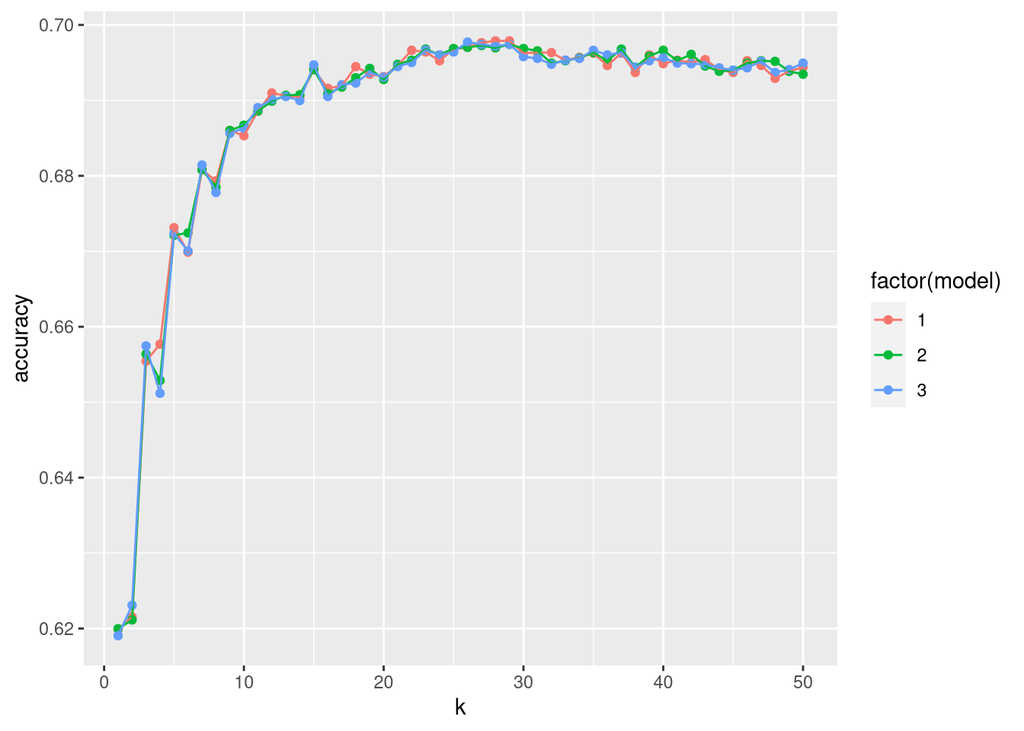

```r
  # First let's use the knn algorithm and see if there is any patterns it can draw on

  # Colnames of all available variables
  var_cols1 = c("age", "gender", "height", "weight", "ap_hi", "ap_lo", "cholesterol", "gluc", "smoke", "alco", "active")
  var_cols2 = c("age", "gender", "height", "weight", "ap_hi", "ap_lo", "cholesterol", "gluc", "active")
  var_cols3 = c("age", "height", "weight", "ap_hi", "ap_lo", "cholesterol", "gluc", "active")

  # Going to run for a number of values of k for the clustering
  knn_accs1 = sapply(1:50, function(x){
    confusionMatrix(test_cardio_data$disease, knn( train=train_cardio_data[var_cols1], test=test_cardio_data[var_cols1], cl=train_cardio_data$disease, k=x))$overall['Accuracy']
  })

  knn_accs2 = sapply(1:50, function(x){
    confusionMatrix(test_cardio_data$disease, knn( train=train_cardio_data[var_cols2], test=test_cardio_data[var_cols2], cl=train_cardio_data$disease, k=x))$overall['Accuracy']
  })

  knn_accs3 = sapply(1:50, function(x){
    confusionMatrix(test_cardio_data$disease, knn( train=train_cardio_data[var_cols3], test=test_cardio_data[var_cols3], cl=train_cardio_data$disease, k=x))$overall['Accuracy']
  })

  # So we aren't able to directly visualize what's being identified here but we can take a look at the accuracies of each model created with a different value of k
  knn_models = rbind(data.frame(k=1:50, accuracy=knn_accs1, model="1"), data.frame(k=1:50, accuracy=knn_accs2, model="2"), data.frame(k=1:50, accuracy=knn_accs3, model="3"))
  ggplot(knn_models, aes(x=k, y=accuracy, color=factor(model))) +
    geom_point() +
    geom_line()
```

So there seems to be a point to which the accuracy of knn will max out, and for most of the cluster analysis that are run with various combinations of columns. The unfortunate part is that it maxes out around the same rate as the multivariate logistic models. They have relatively the same amount of accuracy, and the most effective value of k is around 25. This does make me question the accuracy or improvements that those columns I parsed out of the column sets, if they didn’t have any noticeable effect on the accuracy of the knn cluster analysis. That would lead me to believe that for a cluster analysis the variables that provide the best value are in var_cols3, and it is possible to remove more of those.

## Gender Differences

Now that we have done enough analysis for some of this we are going to look at the same types of analysis but we are going to separate out the datasets based on gender and try to rebuild the same models and test their accuracy. The question becomes if we build separate models for different genders, can we improve the accuracy of one or more models. This time instead of just looking at the raw results here we are going to visualize them.

```r
  # Split training data by the
  training_index_gen1    = sample(1:nrow(clean_cardio_data[ clean_cardio_data$gender==1, ]), size=round(nrow(clean_cardio_data[ clean_cardio_data$gender==1, ])*0.8))
  train_cardio_data_gen1 = clean_cardio_data[ training_index_gen1, ]
  test_cardio_data_gen1  = clean_cardio_data[-training_index_gen1, ]

  training_index_gen2    = sample(1:nrow(clean_cardio_data[ clean_cardio_data$gender==2, ]), size=round(nrow(clean_cardio_data[ clean_cardio_data$gender==2, ])*0.8))
  train_cardio_data_gen2 = clean_cardio_data[ training_index_gen2, ]
  test_cardio_data_gen2  = clean_cardio_data[-training_index_gen2, ]

  # No re-run and test the accuracy of some of the better performing models to limit our scope here, but simply removing gender as a variable in these sets
  m_glm1_gen1 = glm(cardio ~ age + weight + ap_hi + ap_lo + cholesterol + gluc, train_cardio_data_gen1, family=binomial)
  summary(m_glm1_gen1)
```

```
##
## Call:
## glm(formula = cardio ~ age + weight + ap_hi + ap_lo + cholesterol +
##     gluc, family = binomial, data = train_cardio_data_gen1)
##
## Deviance Residuals:
##     Min       1Q   Median       3Q      Max
## -2.9681  -0.9206  -0.2688   0.9254   2.4948
##
## Coefficients:
##               Estimate Std. Error z value Pr(>|z|)
## (Intercept) -1.293e+01  1.902e-01 -67.948  < 2e-16 ***
## age          1.362e-04  5.283e-06  25.784  < 2e-16 ***
## weight       8.721e-03  9.539e-04   9.143  < 2e-16 ***
## ap_hi        6.206e-02  1.418e-03  43.758  < 2e-16 ***
## ap_lo        1.544e-02  2.402e-03   6.427 1.30e-10 ***
## cholesterol  5.201e-01  2.247e-02  23.147  < 2e-16 ***
## gluc        -1.279e-01  2.543e-02  -5.029 4.94e-07 ***
## ---
## Signif. codes:  0 '***' 0.001 '**' 0.01 '*' 0.05 '.' 0.1 ' ' 1
##
## (Dispersion parameter for binomial family taken to be 1)
##
##     Null deviance: 46317  on 33410  degrees of freedom
## Residual deviance: 37599  on 33404  degrees of freedom
## AIC: 37613
##
## Number of Fisher Scoring iterations: 4
```

```r
  conf_matx1_gen1 = confusionMatrix(table(test_cardio_data_gen1$cardio, round(predict(m_glm1_gen1, test_cardio_data_gen1, type="response"))) )

  m_glm2_gen1 = glm(cardio ~ age + weight + ap_hi + ap_lo + cholesterol + gluc + active, train_cardio_data_gen1, family=binomial)
  summary(m_glm2_gen1)
```

```
##
## Call:
## glm(formula = cardio ~ age + weight + ap_hi + ap_lo + cholesterol +
##     gluc + active, family = binomial, data = train_cardio_data_gen1)
##
## Deviance Residuals:
##     Min       1Q   Median       3Q      Max
## -2.9547  -0.9177  -0.2706   0.9233   2.5170
##
## Coefficients:
##               Estimate Std. Error z value Pr(>|z|)
## (Intercept) -1.274e+01  1.915e-01 -66.539  < 2e-16 ***
## age          1.362e-04  5.289e-06  25.751  < 2e-16 ***
## weight       8.634e-03  9.550e-04   9.040  < 2e-16 ***
## ap_hi        6.219e-02  1.420e-03  43.800  < 2e-16 ***
## ap_lo        1.550e-02  2.405e-03   6.443 1.17e-10 ***
## cholesterol  5.231e-01  2.248e-02  23.264  < 2e-16 ***
## gluc        -1.317e-01  2.545e-02  -5.176 2.27e-07 ***
## active      -2.480e-01  3.124e-02  -7.940 2.02e-15 ***
## ---
## Signif. codes:  0 '***' 0.001 '**' 0.01 '*' 0.05 '.' 0.1 ' ' 1
##
## (Dispersion parameter for binomial family taken to be 1)
##
##     Null deviance: 46317  on 33410  degrees of freedom
## Residual deviance: 37536  on 33403  degrees of freedom
## AIC: 37552
##
## Number of Fisher Scoring iterations: 4
```

```r
  conf_matx2_gen1 = confusionMatrix(table(test_cardio_data_gen1$cardio, round(predict(m_glm2_gen1, test_cardio_data_gen1, type="response"))) )

  m_glm3_gen1 = glm(cardio ~ age + weight + ap_hi + ap_lo + cholesterol + gluc + smoke + alco + active, train_cardio_data_gen1, family=binomial)
  summary(m_glm3_gen1)
```

```
##
## Call:
## glm(formula = cardio ~ age + weight + ap_hi + ap_lo + cholesterol +
##     gluc + smoke + alco + active, family = binomial, data = train_cardio_data_gen1)
##
## Deviance Residuals:
##     Min       1Q   Median       3Q      Max
## -2.9300  -0.9178  -0.2707   0.9234   2.5105
##
## Coefficients:
##               Estimate Std. Error z value Pr(>|z|)
## (Intercept) -1.276e+01  1.917e-01 -66.527  < 2e-16 ***
## age          1.344e-04  5.298e-06  25.370  < 2e-16 ***
## weight       9.179e-03  9.594e-04   9.567  < 2e-16 ***
## ap_hi        6.243e-02  1.422e-03  43.892  < 2e-16 ***
## ap_lo        1.548e-02  2.407e-03   6.432 1.26e-10 ***
## cholesterol  5.274e-01  2.252e-02  23.418  < 2e-16 ***
## gluc        -1.344e-01  2.549e-02  -5.272 1.35e-07 ***
## smoke       -1.887e-01  4.779e-02  -3.949 7.84e-05 ***
## alco        -2.508e-01  6.095e-02  -4.116 3.86e-05 ***
## active      -2.409e-01  3.127e-02  -7.702 1.34e-14 ***
## ---
## Signif. codes:  0 '***' 0.001 '**' 0.01 '*' 0.05 '.' 0.1 ' ' 1
##
## (Dispersion parameter for binomial family taken to be 1)
##
##     Null deviance: 46317  on 33410  degrees of freedom
## Residual deviance: 37487  on 33401  degrees of freedom
## AIC: 37507
##
## Number of Fisher Scoring iterations: 4
```

```r
  conf_matx3_gen1 = confusionMatrix(table(test_cardio_data_gen1$cardio, round(predict(m_glm3_gen1, test_cardio_data_gen1, type="response"))) )


  m_glm1_gen2 = glm(cardio ~ age + weight + ap_hi + ap_lo + cholesterol + gluc, train_cardio_data_gen2, family=binomial)
  summary(m_glm1_gen2)
```

```
##
## Call:
## glm(formula = cardio ~ age + weight + ap_hi + ap_lo + cholesterol +
##     gluc, family = binomial, data = train_cardio_data_gen2)
##
## Deviance Residuals:
##     Min       1Q   Median       3Q      Max
## -2.7974  -0.9218  -0.4274   0.9386   2.4632
##
## Coefficients:
##               Estimate Std. Error z value Pr(>|z|)
## (Intercept) -1.283e+01  2.566e-01 -49.998  < 2e-16 ***
## age          1.337e-04  7.121e-06  18.780  < 2e-16 ***
## weight       9.226e-03  1.297e-03   7.116 1.11e-12 ***
## ap_hi        5.860e-02  1.888e-03  31.040  < 2e-16 ***
## ap_lo        1.947e-02  3.214e-03   6.058 1.38e-09 ***
## cholesterol  4.871e-01  3.024e-02  16.109  < 2e-16 ***
## gluc        -1.003e-01  3.401e-02  -2.950  0.00318 **
## ---
## Signif. codes:  0 '***' 0.001 '**' 0.01 '*' 0.05 '.' 0.1 ' ' 1
##
## (Dispersion parameter for binomial family taken to be 1)
##
##     Null deviance: 25132  on 18132  degrees of freedom
## Residual deviance: 20560  on 18126  degrees of freedom
## AIC: 20574
##
## Number of Fisher Scoring iterations: 4
```

```r
  conf_matx1_gen2 = confusionMatrix(table(test_cardio_data_gen2$cardio, round(predict(m_glm1_gen2, test_cardio_data_gen2, type="response"))) )

  m_glm2_gen2 = glm(cardio ~ age + weight + ap_hi + ap_lo + cholesterol + gluc + active, train_cardio_data_gen2, family=binomial)
  summary(m_glm2_gen2)
```

```
##
## Call:
## glm(formula = cardio ~ age + weight + ap_hi + ap_lo + cholesterol +
##     gluc + active, family = binomial, data = train_cardio_data_gen2)
##
## Deviance Residuals:
##     Min       1Q   Median       3Q      Max
## -2.7832  -0.9182  -0.4211   0.9337   2.4886
##
## Coefficients:
##               Estimate Std. Error z value Pr(>|z|)
## (Intercept) -1.263e+01  2.582e-01 -48.927  < 2e-16 ***
## age          1.334e-04  7.129e-06  18.709  < 2e-16 ***
## weight       9.110e-03  1.299e-03   7.015 2.30e-12 ***
## ap_hi        5.882e-02  1.890e-03  31.117  < 2e-16 ***
## ap_lo        1.957e-02  3.219e-03   6.081 1.20e-09 ***
## cholesterol  4.921e-01  3.027e-02  16.258  < 2e-16 ***
## gluc        -1.039e-01  3.405e-02  -3.050  0.00229 **
## active      -2.711e-01  4.219e-02  -6.426 1.31e-10 ***
## ---
## Signif. codes:  0 '***' 0.001 '**' 0.01 '*' 0.05 '.' 0.1 ' ' 1
##
## (Dispersion parameter for binomial family taken to be 1)
##
##     Null deviance: 25132  on 18132  degrees of freedom
## Residual deviance: 20518  on 18125  degrees of freedom
## AIC: 20534
##
## Number of Fisher Scoring iterations: 4
```

```r
  conf_matx2_gen2 = confusionMatrix(table(test_cardio_data_gen2$cardio, round(predict(m_glm2_gen2, test_cardio_data_gen2, type="response"))) )

  m_glm3_gen2 = glm(cardio ~ age + weight + ap_hi + ap_lo + cholesterol + gluc + smoke + alco + active, train_cardio_data_gen2, family=binomial)
  summary(m_glm3_gen2)
```

```
##
## Call:
## glm(formula = cardio ~ age + weight + ap_hi + ap_lo + cholesterol +
##     gluc + smoke + alco + active, family = binomial, data = train_cardio_data_gen2)
##
## Deviance Residuals:
##     Min       1Q   Median       3Q      Max
## -2.7925  -0.9193  -0.4186   0.9354   2.4846
##
## Coefficients:
##               Estimate Std. Error z value Pr(>|z|)
## (Intercept) -1.264e+01  2.583e-01 -48.923  < 2e-16 ***
## age          1.325e-04  7.137e-06  18.563  < 2e-16 ***
## weight       9.410e-03  1.304e-03   7.215 5.41e-13 ***
## ap_hi        5.890e-02  1.891e-03  31.143  < 2e-16 ***
## ap_lo        1.961e-02  3.219e-03   6.092 1.12e-09 ***
## cholesterol  4.933e-01  3.029e-02  16.287  < 2e-16 ***
## gluc        -1.049e-01  3.408e-02  -3.080  0.00207 **
## smoke       -1.191e-01  6.366e-02  -1.871  0.06140 .
## alco        -9.114e-02  8.063e-02  -1.130  0.25831
## active      -2.676e-01  4.221e-02  -6.340 2.29e-10 ***
## ---
## Signif. codes:  0 '***' 0.001 '**' 0.01 '*' 0.05 '.' 0.1 ' ' 1
##
## (Dispersion parameter for binomial family taken to be 1)
##
##     Null deviance: 25132  on 18132  degrees of freedom
## Residual deviance: 20511  on 18123  degrees of freedom
## AIC: 20531
##
## Number of Fisher Scoring iterations: 4
```

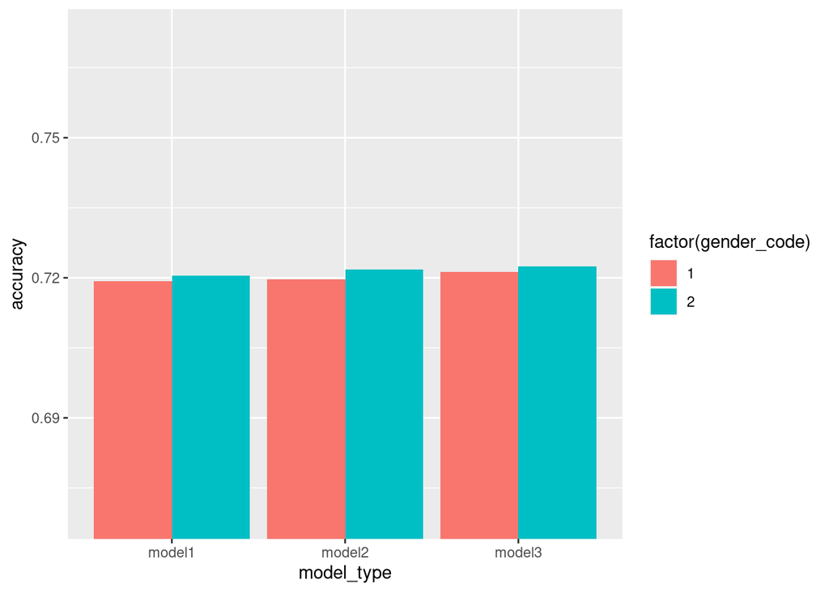

```r
  conf_matx3_gen2 = confusionMatrix(table(test_cardio_data_gen2$cardio, round(predict(m_glm3_gen2, test_cardio_data_gen2, type="response"))) )

  # Now to create a dataframe with the accuracies of all of these models and visualize them in a comparisson4
  accs_models_gens_c = c(conf_matx1_gen1$overall["Accuracy"], conf_matx2_gen1$overall["Accuracy"], conf_matx3_gen1$overall["Accuracy"],
                         conf_matx1_gen2$overall["Accuracy"], conf_matx2_gen2$overall["Accuracy"], conf_matx3_gen2$overall["Accuracy"]
                       )

  accs_models_gen_df = data.frame(
    gender_code = c(1, 1, 1, 2, 2, 2),
    model_type  = c("model1", "model2", "model3", "model1", "model2", "model3"),
    accuracy = accs_models_gens_c
  )

  # Going to create a barchart here
  ggplot(accs_models_gen_df, aes(x=model_type, y=accuracy, fill=factor(gender_code))) +
    geom_bar(stat="identity", position=position_dodge()) +
    # Our data is so close and we know the max here so we are gonig to scale y here
    coord_cartesian(ylim=c(min(accs_models_gens_c)-0.05,max(accs_models_gens_c)+0.05))
```

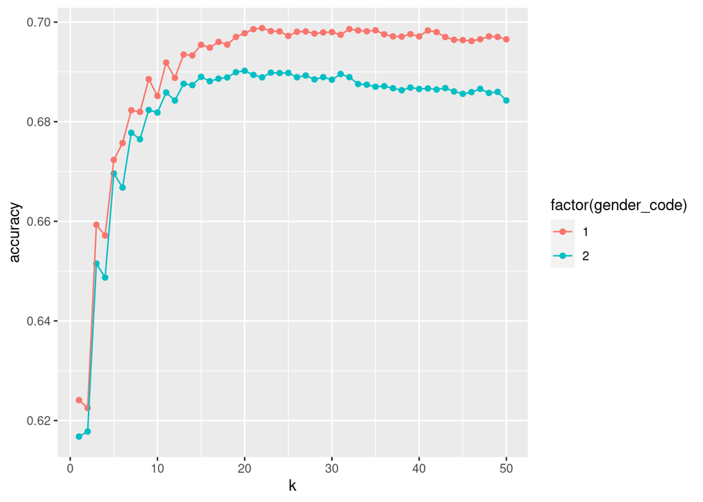

```r
  # Finally let's take a look at the clustering model between the two, and comparsre the accuracy of both
  var_cols_gen = c("age", "height", "weight", "ap_hi", "ap_lo", "cholesterol", "gluc", "active")

  knn_accs_gen1 = sapply(1:50, function(x){
    confusionMatrix(test_cardio_data_gen1$disease, knn( train=train_cardio_data_gen1[var_cols_gen], test=test_cardio_data_gen1[var_cols_gen], cl=train_cardio_data_gen1$disease, k=x))$overall['Accuracy']
  })

  knn_accs_gen2 = sapply(1:50, function(x){
    confusionMatrix(test_cardio_data_gen2$disease, knn( train=train_cardio_data_gen2[var_cols_gen], test=test_cardio_data_gen2[var_cols_gen], cl=train_cardio_data_gen2$disease, k=x))$overall['Accuracy']
  })

  # Very similarly to our previous cluster analysis accuracies comparison, we are goint to look at these accruacis in a line plot
  knn_models_gen = rbind(data.frame(k=1:50, accuracy=knn_accs_gen1, gender_code="1"), data.frame(k=1:50, accuracy=knn_accs_gen2, gender_code="2"))
  ggplot(knn_models_gen, aes(x=k, y=accuracy, color=factor(gender_code))) +
    geom_point() +
    geom_line()
```

## Future Works

What should be done in the future is by gathering more objective data where possible, and attempting new patterns to both slice up the data and create new models that may have better predictions performance.